# Etude qualitative des solutions des équations différentielles

Gustavo Magaña López

24/03/2021

```r
library(tidyverse)
library(deSolve)
library(rootSolve)
```

## Étude qualitative des solutions d’une ED

### Recherche des états stationnaires (ES)

Si l’on a une équation à une seule variable

$$\frac{dx}{dt} = f(x, p_k)$$

où $p_k$ est l’ensemble des paramètres de l’ED, les états stationnaires, s’ils existent seront identifiés par les valeurs $x^\star$ ? annulant la fonction $f : f (x^\star, p_k ) = 0$

Soit une équation différentielle

$$\frac{dx}{dt} = f_1(x) - f_2(x)$$
où

$$f_1(x) = k_0\left(1 + \frac{1}{x}\right)$$

$$f_2(x) = k_1x^\alpha$$

avec $k_0 = 10$, $k_1 = 150$ et $\alpha = 1.5$

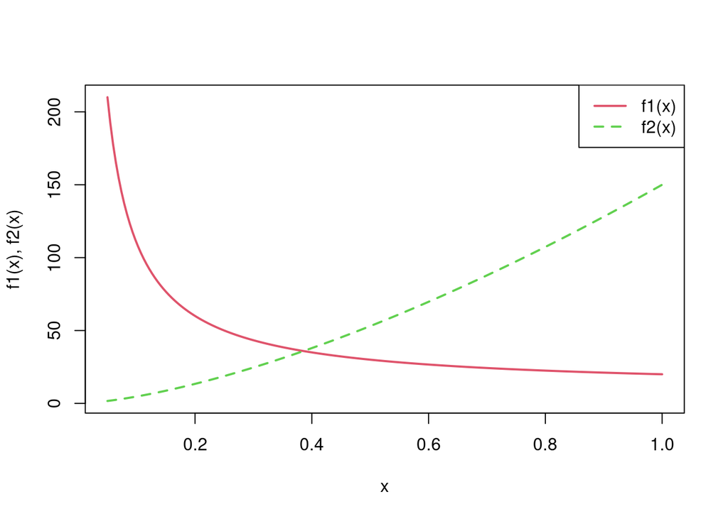

```r
k0 <- 10; k1 <- 150; a <-1.5
f1 <- function(x) k0*(1+1/x)
f2 <- function(x) k1 * x^a
x <-seq(from=0.05, to=1, length=200)

matplot(
  x, cbind(f1(x),f2(x)), type="l",
  col=2:3, lty=c(1,2),
  lwd=c(2,2), ylab="f1(x), f2(x)"
)
legend(
  "topright",
  c("f1(x)","f2(x)"), col=2:3,
  lty=c(1,2), lwd=c(2,2)
)
```

On peut trouver la racine recherchée grâce à la fonction `uniroot`.

```r
f1 <- function(x) k0*(1+1/x)
f2 <- function(x) k1 * x^a
f  <- function(x) f2(x) - f1(x)

racine <- uniroot(f, lower = 0, upper = 1)
racine
```

```
## $root
## [1] 0.385682
##
## $f.root
## [1] 9.385253e-05
##
## $iter
## [1] 5
##
## $init.it
## [1] NA
##
## $estim.prec
## [1] 6.103516e-05
```

La fonction `uniroot()` ne retourne jamais qu’une seule racine, dans l’intervalle spécifié.

Lorsque plusieurs racines sont susceptibles d’exister, il est préférable d’utiliser une autre fonction, `uniroot.all()` qui retourne, elle, toutes les racines existantes dans l’intervalle indiqué. Cette fonction se trouve dans le `package rootSolve`.

- Soit l’équation

$$\frac{dx}{dt} = f_1(x) − f_2(x)$$

où

$$f_1(x) = ae \left(k_0 + \frac{V_m x^n}{K+x} n \right)$$

et
$$f_2 (x) = kx$$

$k_0 = 0.02$, $K = 5$, $ae = 3$, $V_m = 1$, $k = 0.6$ et $n = 2.5$ et $0 < x < 6$

```r
k0=0.02; K=5; Vm=1; ae=3; k=0.6; n=2.5;
f1 <- function(x) ae *(k0+Vm *x^n /(K + x^n))
f2 <- function(x) k * x

mini=0; maxi=6
x <-seq(from=mini, to=maxi, by=1/200)
matplot(x,cbind(f1(x), f2(x)),type="l",col=c("blue","green"),xlab="x",ylab="f1(x), f2(x)")
racine = uniroot.all(function(x) f1(x)-f2(x), lower=mini, upper=maxi)
racine
```

```
## [1] 0.1034382 1.0851845 4.6049485
```

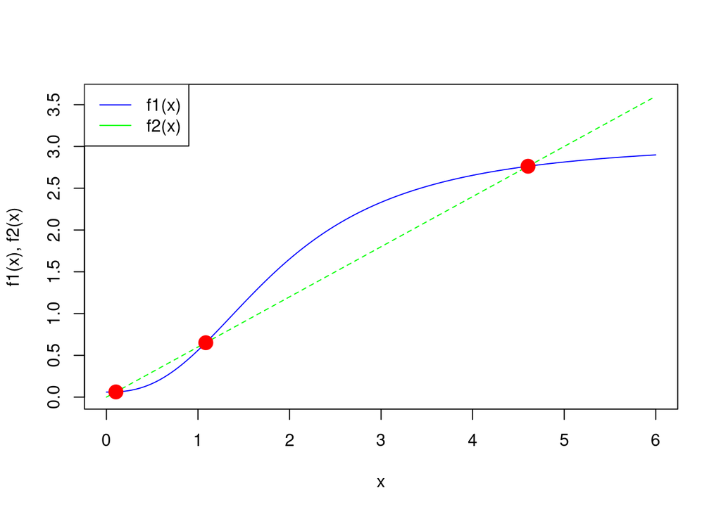

```r
## [1] 0.1034382 1.0851845 4.6049485
points(racine, f1(racine), pch=19, cex=1.8, col="red")
legend("topleft",c("f1(x)","f2(x)"),col=c("blue","green"),lty=1)
```

## Stabilité d’une équation différentielle à une variable

1. Implémenter sous **R** la résolution de l’équation différentielle suivante.

$$x'(t) = (1 - x) c x^a s - x c (1 - x)^a (1 - s)$$

Avec les contraintes :

- $c > 0$
- $a > 1$
- $s \in ]0 ; 1[$

Et conditions initiales :

```r
# ceci était ma première idée mais elle n'est pas compatible avec
# la fonction `ode`
f_from_constants <- function(c, a, s){
  function(x){
    (1 - x) * c * x^a * s - x * c * (1 - x)^a * (1 - s)
  }
}
myfunc <- f_from_constants(3, 2, 0.1)


h <- 0.01
t_0 <- 0
t_f <- 10

temps <- seq(from = t_0, to = t_f, by = h)
parametres <- c(c=3, a=2, s=0.1)
cond_init <- c(x=0.0001)

# TODO : find how to do non-standard evaluation
# providing a symbol or string with the formula
# in order to generalise these functions.
derivee.solver <- function(t, condinit, parametres){
  #' Function to be pased to deSolve::ode()
  with(as.list(c(condinit, parametres)),{
      dx <- (1 - x) * c * x^a * s - x * c * (1 - x)^a * (1 - s)
      return(list(c(dx)))
  })
}

derivee.from.params <- function(parametres){
  #' Generator to yield the derivative fixing the parameters
  with(as.list(c(parametres)),{
      function(x) (1 - x) * c * x^a * s - x * c * (1 - x)^a * (1 - s)
  })
}

x <- ode(y = cond_init, times = temps, func = derivee.solver, parms = parametres)
head(x)
```

```
##      time            x
## [1,] 0.00 1.000000e-04
## [2,] 0.01 9.733651e-05
## [3,] 0.02 9.474395e-05
## [4,] 0.03 9.222043e-05
## [5,] 0.04 8.976434e-05
## [6,] 0.05 8.737357e-05
```

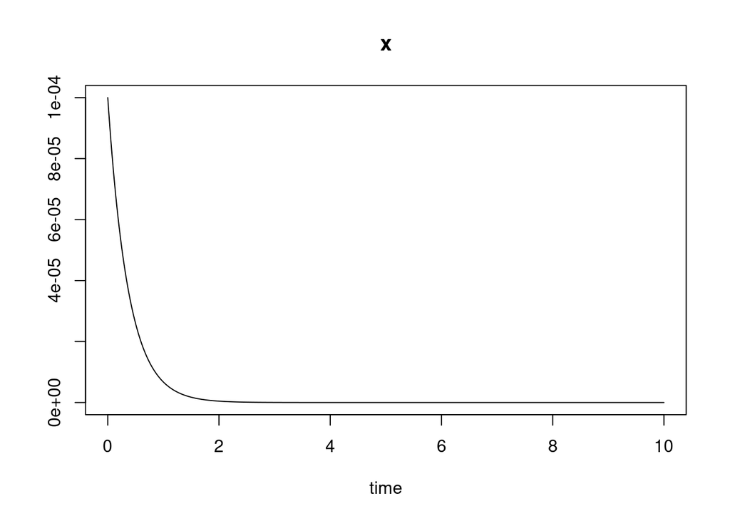

```r
plot(x)
```

2. Existe-t-il une ou des valeurs de conditions initiales (valeurs fixées de $x(0)$) pour lesquelles la solution de l’équation (1) est une constante ?

```r
with(as.list(c(cond_init, parametres)),{
  xstar1 <<- 0
  xstar2 <<- 1
  xstar3 <<- (1+(s/(1-s))^{1/(a-1)})^{-1}
})
```

Oui, en analysant l’équation différentielle on peut observer qu’elle est composée de la différence de deux termes contentant $1 - x$ et $x$, alternant celui qui est élevé à la puissance $a$.

Si ces valeurs existent, que pouvez-vous dire de la limite de la solution de l’équation (1) (lorsque $t \rightarrow \infty$) pour des valeurs de conditions initiales proches des valeurs déterminées à la question précédente ?

Elle est constante, si l’on intègre numériquement à partir d’une valeur nulle, le résultat sera nul aussi.

## Stabilité d’un système d’équation différentielles à deux variables

Implémenter sous R la résolution du système d’équation différentielle suivant

- $x'(t) = -y$
- $y'(t) = x$

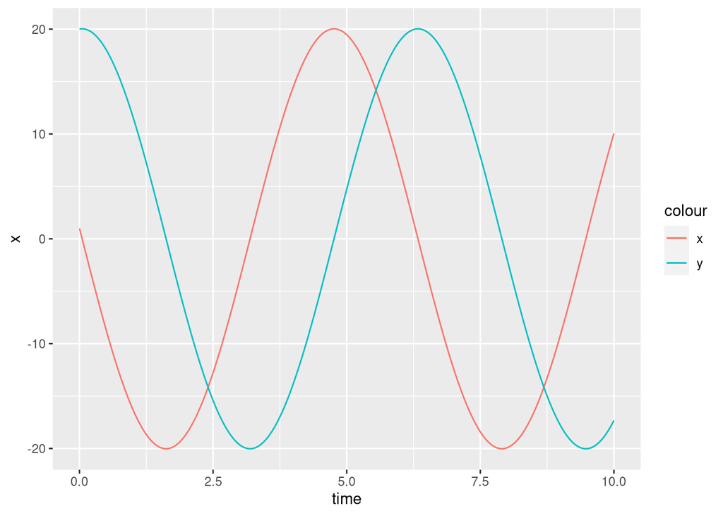

```r
h <- 0.01
t_0 <- 0
t_f <- 10

temps <- seq(from = t_0, to = t_f, by = h)
parametres <- c(c=3, a=2, s=0.1)
cond_init <- c(x=1, y=20)

# TODO : find how to do non-standard evaluation
# providing a symbol or string with the formula
# in order to generalise these functions.
derivee.solver <- function(t, condinit, parametres){
  #' Function to be pased to deSolve::ode()
  with(as.list(c(condinit, parametres)),{
      dx <- -y
      dy <- x
      return(list(c(dx, dy)))
  })
}

xy <- ode(y = cond_init, times = temps, func = derivee.solver, parms = parametres)
xy %>% as.data.frame() %>% tibble() %>%
  ggplot(aes(x=time)) +
    geom_line(aes(y=x, colour="x")) +
    geom_line(aes(y=y, colour="y"))
```

Existe-t-il une ou des valeurs de conditions initiales (valeurs fixées de $x(0)$, $y(0)$) pour lesquelles la solution du système (2) est constante?

Oui, $(x, y)(t_0) = (0, 0)$.

Que pouvez-vous dire de la stabilité de ces états stationnaires ?